<?xml version="1.0" encoding="utf-8" ?>

# The Effect of Migrant Diversity on Household’s Consumption Patterns

Timothy Lin

6 July 2017

# Background & Motivation

- The share of foreign born in the U.S. has seen a sharp increase from 1970 to 2010

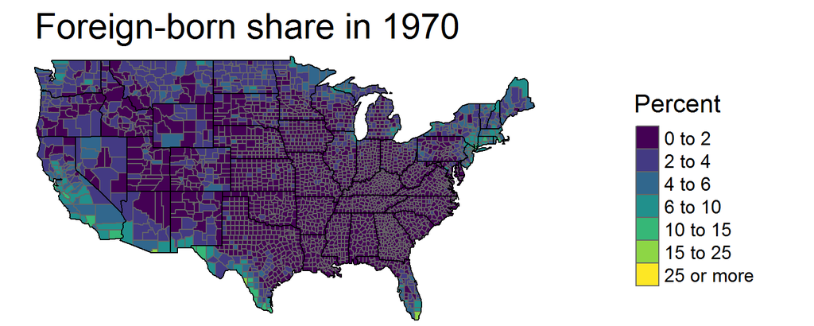

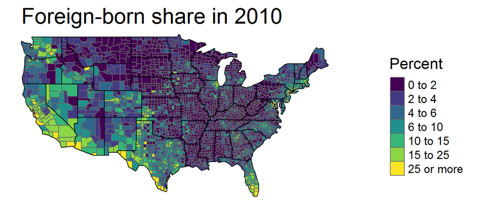

# Background & Motivation

- There is also substantial variation in the diversity and intensity of migrant inflow across counties

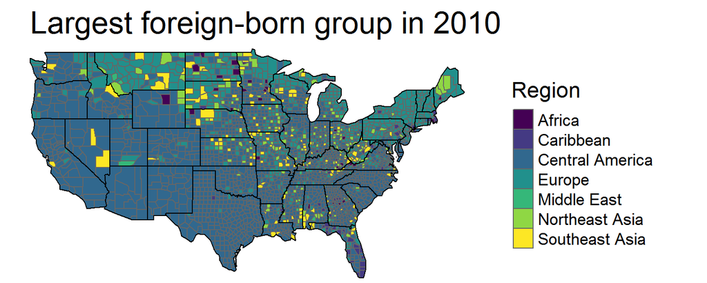

- How do these settlement patterns shape local communities and preferences?
- The different consumption and food culture across countries / regions provide an opportunity to test the spillover effects of migrant culture
- Observationally there seem to be a link between the popularity of certain types of cuisine and a city’s main migrant group

# Research question

- **What is the effect of migration on local household’s food consumption expenditure?**

### Literature review

- A substantial amount of work has been done to study the effect of migration on wages(Card 1990; Borjas 2003; S. P. Kerr and Kerr 2011), but analysis on the broader multidimensional effects of migration is more limited
- Existing work on cultural diversity tends to focus on its economic value measured through outcomes on wages and housing (Ottaviano and Peri 2006; Bellini et al. 2013) or innovation (W. R. Kerr and Lincoln 2010; Hunt and Gauthier-Loiselle 2010)
- Related to Bronnenberg, Dubé, and Gentzkow (2012) who show that the preferences of interstate migrants within the US over consumer packaged goods converge slowly to native preferences

### Key contributions

- This paper extends the literature on the economics of migration and culture by studying a new outcome measure (household food consumption)
- Methodologically, this papwe applies text classification methods on the product attributes field of the Nielsen consumer panel dataset to construct a measure of foreign-linked expenditure

# Model

### Consumer

CES, Dixit and Stiglitz (1977) type model

$$\begin{align}
U_{i} & = C^{\alpha_{i}}_{i}F^{1-\alpha_{i}}_{i} \\
F_{i} &= \left( \sum_{j=1}^{N} \beta_j^{\frac{1}{\sigma}} x_j^{\frac{\sigma -1 }{\sigma}} \right) ^\frac{\sigma}{\sigma - 1}
\end{align}$$
Relative demand:
$$\frac{x_j}{x_k} = \frac{\beta_j}{\beta_k} \left( \frac{p_k}{p_j} \right)^\sigma$$

Summing over all products we obtain:
$$m = \sum_{j=1}^{N} p_j x_j = \left( \sum_{j=1}^{N} \frac{\beta_j}{\beta_k} p_j^{1-\sigma}\right) p_k^\sigma x_k$$

Marshallian demand:
$$\begin{align}
x_k &= \frac{m p_k^{-\sigma}}{\sum_{j=1}^{N} \frac{\beta_j}{\beta_k}p_j^{1-\sigma}} \\
&= \frac{\beta_k m}{p_k^\sigma} \left( \sum_{j=1}^{N} \beta_j p_j^{1-\sigma} \right)^{-1} \\
&= \frac{\beta_k m}{P} \left( \frac{P}{p_k}\right)^\sigma
\end{align}$$
Expenditure share:
$$s_j = \beta_j \left( \frac{P}{p_j}\right)^{\sigma-1}$$
Holding price constant, an increase in $\beta$ increases the associated expenditure share.

### Producer

Assume single product firms engaging in Bertrand price competition

Profit function:

$$\pi_i = p_i x_i - c_i x_i - F_i$$

F.O.C

$$\begin{align}
0 &= x_i + p_i \frac{\partial x_i}{\partial p_i} - c_i \frac{\partial x_i}{\partial p_i} \\
c_i &= \left( 1 + \frac{1}{\varepsilon_d}\right)p_i \\
&= \left( 1 - \frac{1}{\sigma}\right)p_i
\end{align}$$

Product $i$ is imported if profit is higher than fixed cost

$$(p_i - c_i)x_i \geq F_i$$

Equilibrium (assuming identical consumers):

$$\frac{F_i}{p_i -c} = \frac{\beta_i m}{P} \left( \frac{P}{p_i}\right)^\sigma$$

Challenges in identifying changes in consumer’s preferences:

- Variety of goods is endogenous
- Hard to distinguish between preference and cost channels

Nevertheless, an increase in migrant flow is theorised to lead to an increase in consumption share

# Data

- Nielsen consumer panel dataset
  - Detailed information on household shopping trips, purchases and amount spent
  - Used 2011 cross-section containing 62,000 households. Focus on white, non-hispanic, expenditure in 8 categories:
    - canned seafood, canned vegetables, dry mix, frozen, pasta, ready-to-serve, sauces, spices
  - Merged with products attributes dataset
- Recipe corpus
  - Scraped 6275 recipes with 25 different geographical region tags from [allrecipe.com](http://allrecipes.com/recipes/86/world-cuisine/)
  - Combined with data from 165 recipe books’ indexes.
- Foreign born data
  - Used 5-year 2006-2010 ACS and 1980 census data from NHGIS
  - Additional robustness test conducted over choice of dataset

# Data

- 65,600 unique UPC codes in the initial dataset
- Merged UPC codes to type description and product description fields depending on which provide more information to create a vector of search text
- Excluded the following categories: misc. sauces, sandwich spreads meat, extracts, vegetables onion instant, multipack, soup
- Product description fields are quite sparse and contain basic information on product characteristic / flavour e.g. “mahi mahi mango marinaded”, “fajita seasoning”, “beans”
- Search text is subsequently merged with the TF-IDF dataset to create geographical region weights for 47,000 UPC codes
- Search text is merged to two versions of the recipe TF-IDF scores, single word and word pairs
- The word pair score is used if such a merge exists, otherwise the single word match with the highest maximum score is used e.g. “fajita seasoning” would be given the TF-IDF score of “fajita seasoning” if it exists, else it would be assigned the maximum of “fajita” and “seasoning”

# Measuring region-linked expenditure shares

- Implemented a bag-of-words model commonly used in document classification problems
- Similar studies using text classification include Antweiler and Frank (2004) and Gentzkow and Shapiro (2010)
- Term frequency - inverse document frequency (TF-IDF) method:
  - Use the relative frequency of words/ingredients for a particular region as a signal of importance
  - “Normalise” the term frequencies by the inverse document frequency to down-weight common words

$$TF\text{-}IDF_{t,d} =\frac{f_{t,d}}{\sum_{t'\in d}f_{t',d}} \cdot log \frac{N}{n_{t}+1}$$

- where $f_{t,d}$ is the frequency in which term $t$ appears in document $d$
- $N$ is the total number of documents in the corpus and $n_{t}$ is the total number of documents where term $t$ is found
- The TF-IDF approach is commonly used in document classification problems and usually out performs multinomial naive bayes (Kibriya et al. 2004)

# Word frequencies from the recipe dataset

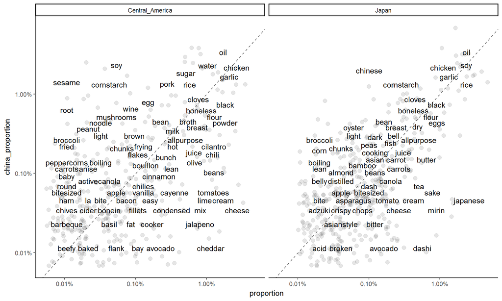

# Visualising TF-IDF scores

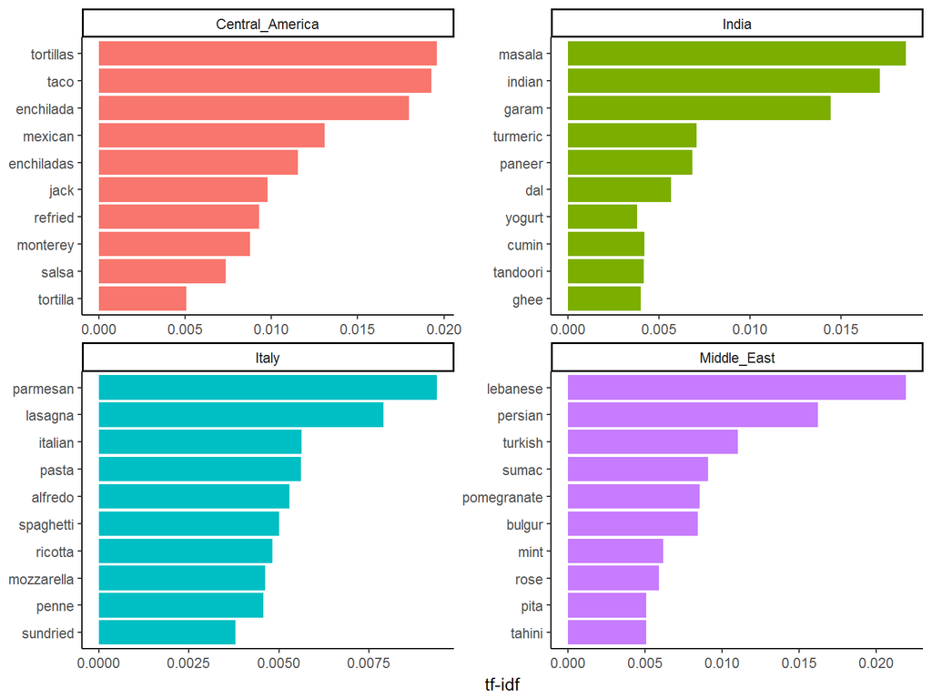

# From TF-IDF scores to weights

- Calculate TF-IDF scores for recipe and book dataset ($\rho$=0.77) and take the simple average
- Match the TF-IDF scores to the product attribute dataset and normalise scores across each product
- Use the weights to calculate linked-expenditure shares
- Sample of products

# Empricial Strategy

$$Exp\_share_{ij} = \rho FB\_share_{ij} + \mu ln\_dist_{ij} + \lambda_{i} + \gamma_{j} +\epsilon_{ij}$$

- Control for unobserved variation at the county($i$) and geographical-region($j$) level as well as log great circle distance between county and region.
- Omitted variable problem not a main concern. While many factors affect foreign-born share, few, if any are correlated with local food expenditure share
- Potential “peer effects” endogeneity concerns(Angrist 2014) e.g. similar preferences between parent and child of common ancestry
- Solution: restrict the foreign-born share sample to non-European countries

# Empricial Strategy

- Measurement error is still a large source of concern
- Use 1980 foreign-born share as an instrument
- Foreign enclave idea (Card 2001; Ottaviano and Peri 2006). Exploit persistent migrant flow patterns that are plausibly orthogonal to consumption
- Furthermore, the time period also coincides with the liberalisation of U.S. migration policy
- The Immigration and Naturalization Act of 1965 replaced the national origins quota with a category system
- Distribution of the initial wave of migrant plausibly exogenous to consumption
- Policy change resulted in mass migration primarily from Central America and Asia (Chiswick and Hatton 2003; Abramitzky and Boustan 2016)

# Results (Baseline)

**OLS regression estimates**

|  | *Dependent variable:* |  |  |  |  |  |
| --- | --- | --- | --- | --- | --- | --- |
|  | Exp Share |  |  |  |  |  |
|  | (1) | (2) | (3) | (4) | (5) | (6) |
| 2010 FB Share | 0.1619*** | 0.0011 | 0.3312 | 0.0791 | 0.1764*** | -0.0490 |
|  | (0.0558) | (0.0174) | (0.2501) | (0.1480) | (0.0593) | (0.0365) |
| Sample | Full | Asia | Full | Asia | Full | Asia |
| Geographical region FE | X | X |  |  | X | X |
| County FE |  |  | X | X | X | X |
| Observations | 796,448 | 448,002 | 796,448 | 448,002 | 796,448 | 448,002 |
| Notes: Two-way standard errors clustered by county and geographical region in parentheses. |  |  |  |  |  |  |
| Full sample consists of 18 regions, Asia sample consists of 9 regions. |  |  |  |  |  |  |
| *p<0.1; **p<0.05; ***p<0.01 |  |  |  |  |  |  |

# Results (IV)

**IV Estimates**

|  | *Dependent variable:* |  |  |  |  |  |
| --- | --- | --- | --- | --- | --- | --- |
|  | Exp Share |  | 2010 FB Share | Exp Share | 2010 FB Share | Exp Share |
|  | OLS | OLS Subset | First Stage | IV | First Stage | IV |
|  | (1) | (2) | (3) | (4) | (5) | (6) |
| 2010 FB Share | 0.1764*** | 0.2004*** |  |  |  |  |
|  | (0.0593) | (0.0426) |  |  |  |  |
| 1980 FB Share |  |  | 1.8307*** |  | 2.1091*** |  |
|  |  |  | (0.1778) |  | (0.2753) |  |
| Fitted 2010 FB Share |  |  |  | 0.2762*** |  | -0.1337** |
|  |  |  |  | (0.0480) |  | (0.0669) |
| First Stage F-stat |  |  | 105.99 |  | 58.71 |  |
| Sample | Full | Full | Full | Full | Asia | Asia |
| Geographical region FE | X | X | X | X | X | X |
| County FE | X | X | X | X | X | X |
| Observations | 796,448 | 595,920 | 595,932 | 595,920 | 248,305 | 248,300 |
| Notes: Two-way standard errors clustered by county and geographical region in parentheses. |  |  |  |  |  |  |
| OLS Full sample consists of 18 regions, OLS Subset and IV Full sample consists of 12 regions, IV Asia sample consists of 5 regions. |  |  |  |  |  |  |
| The decrease in the number of observations in the IV sample is due to data availability limitations of the 1980 NHGIS dataset. |  |  |  |  |  |  |
| *p<0.1; **p<0.05; ***p<0.01 |  |  |  |  |  |  |

# Results by product category

**IV Regressions by Product Category**

|  | *Dependent variable:* |  |  |  |  |  |  |  |
| --- | --- | --- | --- | --- | --- | --- | --- | --- |
|  | Category Exp Share |  |  |  |  |  |  |  |
|  | IV | IV | IV | IV | IV | IV | IV | IV |
|  | (1) | (2) | (3) | (4) | (5) | (6) | (7) | (8) |
| Fitted 2010 FB Share | 0.3246*** | -0.0835*** | 0.5860*** | -0.2106 | 0.1438 | -0.1101** | 0.0029 | 0.0205*** |
|  | (0.0559) | (0.0322) | (0.1748) | (0.2660) | (0.1364) | (0.0482) | (0.0204) | (0.0026) |
| Sample | Full | Asia | Full | Asia | Full | Asia | Full | Asia |
| Product category | Frozen | Frozen | Ready-to-serve | Ready-to-serve | Sauces | Sauces | Spice | Spice |
| Geographical region FE | X | X | X | X | X | X | X | X |
| County FE | X | X | X | X | X | X | X | X |
| Observations | 564,672 | 235,280 | 557,076 | 232,115 | 586,908 | 244,545 | 539,172 | 224,655 |
| Notes: Two-way standard errors clustered by county and geographical region in parentheses. |  |  |  |  |  |  |  |  |
| IV Full sample consists of 12 regions, IV Asia sample consists of 5 regions. |  |  |  |  |  |  |  |  |
| The decrease in the number of observations in the IV sample is due to data availability limitations of the 1980 NHGIS dataset. |  |  |  |  |  |  |  |  |
| *p<0.1; **p<0.05; ***p<0.01 |  |  |  |  |  |  |  |  |

# Robustness (measures)

**Robustness Tests (Construction of Expenditure Measure)**

|  | *Dependent variable:* |  |  |  |  |  |
| --- | --- | --- | --- | --- | --- | --- |
|  | Exp Share |  | Exp Share |  | Exp Share |  |
|  | IV | IV | IV | IV | IV | IV |
|  | (1) | (2) | (3) | (4) | (5) | (6) |
| Fitted 2010 FB Share | 0.2762*** | -0.1337** | 0.2854*** | -0.1165 | 0.2818*** | -0.1457** |
|  | (0.0480) | (0.0669) | (0.0484) | (0.0884) | (0.0527) | (0.0593) |
| Sample | Full | Asia | Full | Asia | Full | Asia |
| Expenditure measure | Wtd. Avg | Wtd. Avg | Majority | Majority | High Majority | High Majority |
| Geographical region FE | X | X | X | X | X | X |
| County FE | X | X | X | X | X | X |
| Observations | 595,920 | 248,300 | 595,920 | 248,300 | 595,920 | 248,300 |
| Notes: Two-way standard errors clustered by county and geographical region in parentheses. |  |  |  |  |  |  |
| IV Full sample consists of 12 regions, IV Asia sample consists of 5 regions. |  |  |  |  |  |  |
| Expenditure measure constructed by weighted average (Wtd. Avg) or with weight=1 for the region with highest weight (Majority) |  |  |  |  |  |  |
| or with weight=1 for the region with highest weight conditional on the initial weight being greater than 0.5 (High Majority) |  |  |  |  |  |  |
| *p<0.1; **p<0.05; ***p<0.01 |  |  |  |  |  |  |

# Robustness (datasets)

**Robustness Tests (Different Datasets)**

[output not shown]

# Heterogeneity (migrant dissimilarity index)

**Examining heterogeniety by migrant dissimilarity**

|  | *Dependent variable:* |  |  |  |
| --- | --- | --- | --- | --- |
|  | Exp Share |  |  |  |
|  | OLS | OLS | IV | IV |
|  | (1) | (2) | (3) | (4) |
| 2010 FB Share | 0.1756*** | -0.0549 |  |  |
|  | (0.0589) | (0.0373) |  |  |
| Foreign Dis x 2010 FB Share | -0.0322 |  |  |  |
|  | (0.0408) |  |  |  |
| Asia Dis x 2010 FB Share |  | -0.0130 |  |  |
|  |  | (0.0599) |  |  |
| Fitted 2010 FB Share |  |  | 0.2748*** | -0.2170* |
|  |  |  | (0.0492) | (0.1179) |
| Fitted Foreign Dis x 2010 FB Share |  |  | -0.0126 |  |
|  |  |  | (0.0744) |  |
| Fitted Asia Dis x 2010 FB Share |  |  |  | -0.1494 |
|  |  |  |  | (0.1499) |
| Sample | Full | Asia | Full | Asia |
| Geographical region FE | X | X | X | X |
| County FE | X | X | X | X |
| Observations | 796,256 | 444,537 | 595,776 | 246,375 |
| Notes: Two-way standard errors clustered by county and geographical region in parentheses. |  |  |  |  |
| OLS Full sample consists of 18 regions, IV Full sample consists of 12 regions, IV Asia sample consists of 5 regions. |  |  |  |  |
| The decrease in the number of observations in the IV sample is due to data availability limitations of the 1980 NHGIS dataset. |  |  |  |  |
| *p<0.1; **p<0.05; ***p<0.01 |  |  |  |  |

# Heterogeneity (age)

**Examining heterogeneity by household age**

|  | *Dependent variable:* |  |  |  |
| --- | --- | --- | --- | --- |
|  | Exp Share |  |  |  |
|  | IV | IV | IV | IV |
|  | (1) | (2) | (3) | (4) |
| Fitted 2010 FB Share | 0.2342*** | 0.3086*** | -0.1619 | -0.1218* |
|  | (0.0498) | (0.0531) | (0.1006) | (0.0712) |
| Sample | Full, Young | Full, Old | Asia, Young | Asia, Old |
| Geographical region FE | X | X | X | X |
| County FE | X | X | X | X |
| Observations | 121,404 | 474,516 | 50,585 | 197,715 |
| Notes: Two-way standard errors clustered by county and geographical region in parentheses. |  |  |  |  |
| IV Full sample consists of 12 regions, IV Asia sample consists of 5 regions. |  |  |  |  |
| The decrease in the number of observations in the IV sample is due to data availability limitations of the 1980 NHGIS dataset. |  |  |  |  |
| Young refers to households where the age of male or female head of household is below 45. Old is the complement group. |  |  |  |  |
| *p<0.1; **p<0.05; ***p<0.01 |  |  |  |  |

# Discussion

# Appendix (TF-IDF geographical region correlation matrix)

**Country correlation matrix**

|  | Africa | Caribbean | Central_America | China | Eastern_Europe | France | Germany | Greece | India | Italy | Japan | Korea | Middle_East | Other_Southeast_Asia | Philippines | Scandinavia | South_America | Spain | Thailand | Vietnam |
| --- | --- | --- | --- | --- | --- | --- | --- | --- | --- | --- | --- | --- | --- | --- | --- | --- | --- | --- | --- | --- |
| Africa | 1 | 0.903 | 0.733 | 0.671 | 0.725 | 0.750 | 0.629 | 0.813 | 0.842 | 0.712 | 0.639 | 0.682 | 0.897 | 0.761 | 0.842 | 0.431 | 0.910 | 0.862 | 0.607 | 0.587 |
| Caribbean | 0.903 | 1 | 0.760 | 0.695 | 0.688 | 0.733 | 0.598 | 0.827 | 0.810 | 0.700 | 0.700 | 0.724 | 0.859 | 0.803 | 0.876 | 0.407 | 0.912 | 0.873 | 0.757 | 0.706 |
| Central_America | 0.733 | 0.760 | 1 | 0.555 | 0.576 | 0.638 | 0.457 | 0.693 | 0.734 | 0.705 | 0.540 | 0.558 | 0.658 | 0.623 | 0.692 | 0.308 | 0.729 | 0.655 | 0.603 | 0.623 |
| China | 0.671 | 0.695 | 0.555 | 1 | 0.539 | 0.582 | 0.496 | 0.552 | 0.649 | 0.539 | 0.837 | 0.820 | 0.663 | 0.801 | 0.808 | 0.358 | 0.671 | 0.643 | 0.752 | 0.780 |
| Eastern_Europe | 0.725 | 0.688 | 0.576 | 0.539 | 1 | 0.874 | 0.920 | 0.632 | 0.605 | 0.579 | 0.628 | 0.481 | 0.695 | 0.565 | 0.707 | 0.861 | 0.797 | 0.612 | 0.469 | 0.502 |
| France | 0.750 | 0.733 | 0.638 | 0.582 | 0.874 | 1 | 0.817 | 0.719 | 0.622 | 0.726 | 0.583 | 0.539 | 0.741 | 0.623 | 0.707 | 0.756 | 0.822 | 0.685 | 0.559 | 0.577 |
| Germany | 0.629 | 0.598 | 0.457 | 0.496 | 0.920 | 0.817 | 1 | 0.531 | 0.499 | 0.456 | 0.592 | 0.469 | 0.605 | 0.524 | 0.630 | 0.930 | 0.713 | 0.503 | 0.425 | 0.462 |
| Greece | 0.813 | 0.827 | 0.693 | 0.552 | 0.632 | 0.719 | 0.531 | 1 | 0.638 | 0.796 | 0.559 | 0.572 | 0.822 | 0.654 | 0.733 | 0.371 | 0.808 | 0.829 | 0.578 | 0.590 |
| India | 0.842 | 0.810 | 0.734 | 0.649 | 0.605 | 0.622 | 0.499 | 0.638 | 1 | 0.623 | 0.571 | 0.615 | 0.791 | 0.781 | 0.740 | 0.329 | 0.785 | 0.703 | 0.646 | 0.588 |
| Italy | 0.712 | 0.700 | 0.705 | 0.539 | 0.579 | 0.726 | 0.456 | 0.796 | 0.623 | 1 | 0.503 | 0.535 | 0.698 | 0.592 | 0.668 | 0.334 | 0.740 | 0.684 | 0.518 | 0.608 |
| Japan | 0.639 | 0.700 | 0.540 | 0.837 | 0.628 | 0.583 | 0.592 | 0.559 | 0.571 | 0.503 | 1 | 0.814 | 0.608 | 0.769 | 0.784 | 0.482 | 0.639 | 0.647 | 0.731 | 0.736 |
| Korea | 0.682 | 0.724 | 0.558 | 0.820 | 0.481 | 0.539 | 0.469 | 0.572 | 0.615 | 0.535 | 0.814 | 1 | 0.653 | 0.738 | 0.778 | 0.331 | 0.717 | 0.747 | 0.701 | 0.721 |
| Middle_East | 0.897 | 0.859 | 0.658 | 0.663 | 0.695 | 0.741 | 0.605 | 0.822 | 0.791 | 0.698 | 0.608 | 0.653 | 1 | 0.717 | 0.811 | 0.415 | 0.869 | 0.868 | 0.606 | 0.625 |
| Other_Southeast_Asia | 0.761 | 0.803 | 0.623 | 0.801 | 0.565 | 0.623 | 0.524 | 0.654 | 0.781 | 0.592 | 0.769 | 0.738 | 0.717 | 1 | 0.850 | 0.371 | 0.764 | 0.697 | 0.809 | 0.750 |
| Philippines | 0.842 | 0.876 | 0.692 | 0.808 | 0.707 | 0.707 | 0.630 | 0.733 | 0.740 | 0.668 | 0.784 | 0.778 | 0.811 | 0.850 | 1 | 0.456 | 0.865 | 0.782 | 0.759 | 0.738 |
| Scandinavia | 0.431 | 0.407 | 0.308 | 0.358 | 0.861 | 0.756 | 0.930 | 0.371 | 0.329 | 0.334 | 0.482 | 0.331 | 0.415 | 0.371 | 0.456 | 1 | 0.548 | 0.298 | 0.304 | 0.349 |
| South_America | 0.910 | 0.912 | 0.729 | 0.671 | 0.797 | 0.822 | 0.713 | 0.808 | 0.785 | 0.740 | 0.639 | 0.717 | 0.869 | 0.764 | 0.865 | 0.548 | 1 | 0.840 | 0.656 | 0.624 |
| Spain | 0.862 | 0.873 | 0.655 | 0.643 | 0.612 | 0.685 | 0.503 | 0.829 | 0.703 | 0.684 | 0.647 | 0.747 | 0.868 | 0.697 | 0.782 | 0.298 | 0.840 | 1 | 0.611 | 0.574 |
| Thailand | 0.607 | 0.757 | 0.603 | 0.752 | 0.469 | 0.559 | 0.425 | 0.578 | 0.646 | 0.518 | 0.731 | 0.701 | 0.606 | 0.809 | 0.759 | 0.304 | 0.656 | 0.611 | 1 | 0.839 |
| Vietnam | 0.587 | 0.706 | 0.623 | 0.780 | 0.502 | 0.577 | 0.462 | 0.590 | 0.588 | 0.608 | 0.736 | 0.721 | 0.625 | 0.750 | 0.738 | 0.349 | 0.624 | 0.574 | 0.839 | 1 |

# Appendix (household summary statistics)

**Weighted household expediture shares**

|  | N | Mean | SD | Min | Q25 | Median | Q75 | Max |
| --- | --- | --- | --- | --- | --- | --- | --- | --- |
| household_total_exp | 50,123 | 328.91 | 236.16 | 0 | 164.03 | 277.84 | 435.17 | 4,948 |
| Africa | 50,120 | 0.01 | 0.01 | 0 | 0.01 | 0.01 | 0.01 | 0.47 |
| Caribbean | 50,120 | 0.02 | 0.01 | 0 | 0.02 | 0.02 | 0.03 | 0.54 |
| Central_America | 50,120 | 0.09 | 0.06 | 0 | 0.04 | 0.07 | 0.11 | 1 |
| China | 50,120 | 0.02 | 0.02 | 0 | 0.01 | 0.02 | 0.03 | 0.53 |
| Eastern_Europe | 50,120 | 0.02 | 0.01 | 0 | 0.01 | 0.02 | 0.02 | 0.59 |
| France | 50,120 | 0.02 | 0.01 | 0 | 0.01 | 0.01 | 0.02 | 0.60 |
| Germany | 50,120 | 0.02 | 0.01 | 0 | 0.01 | 0.01 | 0.02 | 0.47 |
| Greece | 50,120 | 0.02 | 0.02 | 0 | 0.01 | 0.02 | 0.03 | 0.30 |
| India | 50,120 | 0.02 | 0.02 | 0 | 0.01 | 0.01 | 0.02 | 0.54 |
| Italy | 50,120 | 0.12 | 0.07 | 0 | 0.07 | 0.10 | 0.15 | 0.96 |
| Japan | 50,120 | 0.03 | 0.03 | 0 | 0.01 | 0.02 | 0.03 | 0.74 |
| Korea | 50,120 | 0.02 | 0.02 | 0 | 0.01 | 0.01 | 0.02 | 0.56 |
| Middle_East | 50,120 | 0.02 | 0.01 | 0 | 0.01 | 0.01 | 0.02 | 0.53 |
| Other_Southeast_Asia | 50,120 | 0.01 | 0.01 | 0 | 0.003 | 0.01 | 0.01 | 0.37 |
| Philippines | 50,120 | 0.02 | 0.01 | 0 | 0.01 | 0.02 | 0.02 | 0.34 |
| Scandinavia | 50,120 | 0.02 | 0.02 | 0 | 0.01 | 0.01 | 0.02 | 0.38 |
| South_America | 50,120 | 0.01 | 0.01 | 0 | 0.01 | 0.01 | 0.02 | 0.42 |
| Spain | 50,120 | 0.02 | 0.02 | 0 | 0.01 | 0.02 | 0.03 | 0.50 |
| Thailand | 50,120 | 0.01 | 0.01 | 0 | 0.01 | 0.01 | 0.02 | 0.92 |
| Vietnam | 50,120 | 0.01 | 0.01 | 0 | 0.001 | 0.003 | 0.01 | 0.41 |

# Appendix (sample of products)

**Sample of products by region and weight**

| Top products by weight | Africa | Caribbean | Central_America | China | Eastern_Europe | France | Germany | Greece | India | Italy | Japan | Korea | Middle_East | Other_Southeast_Asia | Philippines | Scandinavia | South_America | Spain | Thailand | Vietnam |
| --- | --- | --- | --- | --- | --- | --- | --- | --- | --- | --- | --- | --- | --- | --- | --- | --- | --- | --- | --- | --- |
| Score < = 1 | mild moroccan fish | navy bean | pinto bean | spicy kung bowl | beef cholent kugel kishka | watermelon rind | buttery rice | rotini tomato basil | kidney bean | gnocchi potato | sushi wrap rice bowl | barbecued beef pork | bean rice | peanut satay sauce | beef steak pepper | swedish cream | peruvian bean | spanish style rice | thailand fragrant rice | dragon roll |
|  | roasted split turkey breast | baked navy bean | chile tamale | spicy mongolian bowl | string bean | chestnut puree | assorted | grape leaves | rice pilaf | manicotti | umeboshi plum | braised beef chili | pinto bean rice | satay sauce | beef steak dinner | rock roll berry roll | vino seco wine | pork brains canned | fragrant rice | dragon sauce |
|  | spicy moroccan fish | aromatic | cheesy hashbrown | spicy szechuan ramen | string bean potato | gratin potato | sausage hash canned | beef burger stew | madras lentils | gnocchi | sushi ocean crab roll | miso soybean paste | savory bean rice | chile pepper | supreme sushi piece | rutabaga | white vino seco wine | canary bean | buffalo style | vietnamese noodle |
| Score < =0.5 | yellow rice | butterflied shrimp | chilies | hoisin sauce | roast duck sauce | herbs | chervil flakes | macaroni | cayenne | vermouth wine | broiled steak seasoning | rice soup powder | mughlai kofta rice | mild navratan kurma | shrimp spring roll | raisin gcmgbl medley | santa style beef | lobster rangoon | tiger sauce | spicy grass chili rice |
|  | regular yellow rice | island getaway seasoning | rotisserie oven roast seasoning | miso hoisin sauce | smoked bacon | spice herbs | chervil leaves | elbow macaroni | chili cayenne powder | beef portobello | flame broiled cheese beef | pork napa cabbage dumpling | white beans | mild potato spinach rice | spring roll | raisin crispies | mongolian style beef | seafood shrimp lobster newberg sauce fillo | tiger seasoning | grass rice |
|  | lamb stew | shrimp island lime | oven chicken glaze | rakkyo scallion | sour cream chive potato | salad herbs | chervil | shell macaroni | mini whole grain pasta | roast beef gravy | flame broiled fajita chicken | seasoned rotisserie | great northern white beans | mild cstnb | spring roll wrap | country style dijon mustard | style beef | lobster cake maine | sticky rice | chix noodle soup |

# Appendix (distribution of asian foreign-born)

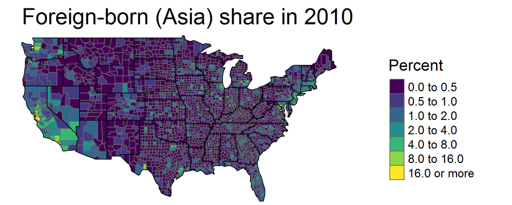

# Appendix (distribution of asian foreign-born )

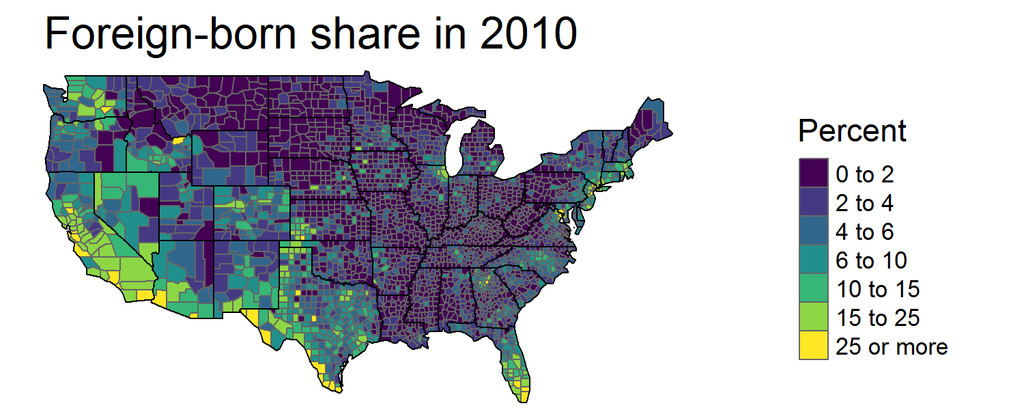

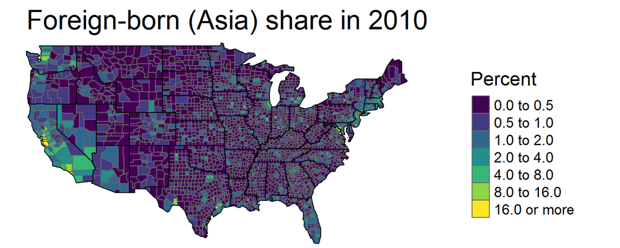

# Appendix (distribution of product weights)

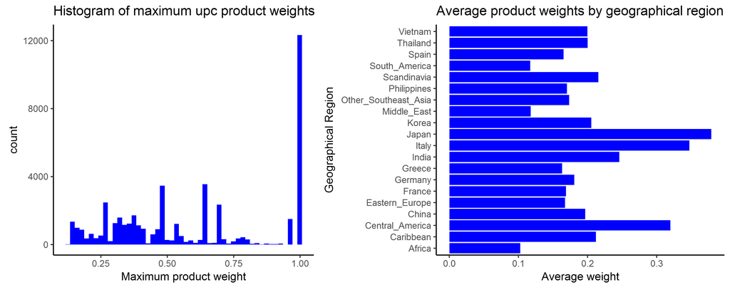

# References

Abramitzky, Ran, and Leah Platt Boustan. 2016. “Immigration in American Economic History.” *Journal of Economic Literature (Forthcoming)*.

Angrist, Joshua D. 2014. “The Perils of Peer Effects.” *Labour Economics* 30. Elsevier: 98–108.

Antweiler, Werner, and Murray Z Frank. 2004. “Is All That Talk Just Noise? The Information Content of Internet Stock Message Boards.” *The Journal of Finance* 59 (3). Wiley Online Library: 1259–94.

Bellini, Elena, Gianmarco IP Ottaviano, Dino Pinelli, and Giovanni Prarolo. 2013. “Cultural Diversity and Economic Performance: Evidence from European Regions.” In *Geography, Institutions and Regional Economic Performance*, 121–41. Springer.

Borjas, George J. 2003. “The Labor Demand Curve Is Downward Sloping: Reexamining the Impact of Immigration on the Labor Market.” *The Quarterly Journal of Economics* 118 (4). Oxford University Press: 1335–74.

Bronnenberg, Bart J., Jean-Pierre H. Dubé, and Matthew Gentzkow. 2012. “The Evolution of Brand Preferences: Evidence from Consumer Migration.” *The American Economic Review* 102 (6). American Economic Association: 2472–2508.

Card, David. 1990. “The Impact of the Mariel Boatlift on the Miami Labor Market.” *ILR Review* 43 (2). SAGE Publications Sage CA: Los Angeles, CA: 245–57.

———. 2001. “Immigrant Inflows, Native Outflows, and the Local Labor Market Impacts of Higher Immigration.” *Journal of Labor Economics* 19 (1). The University of Chicago Press: 22–64.

Chiswick, Barry, and Timothy J. Hatton. 2003. “International Migration and the Integration of Labor Markets.” In *Globalization in Historical Perspective*, edited by Michael D. Bordo, Alan M. Taylor, and Jeffrey G. Williamson, 65–120. Chicago: University of Chicago Press.

Dixit, Avinash K, and Joseph E Stiglitz. 1977. “Monopolistic Competition and Optimum Product Diversity.” *The American Economic Review* 67 (3). JSTOR: 297–308.

Gentzkow, Matthew, and Jesse M Shapiro. 2010. “What Drives Media Slant? Evidence from Us Daily Newspapers.” *Econometrica* 78 (1). Wiley Online Library: 35–71.

Hunt, Jennifer, and Marjolaine Gauthier-Loiselle. 2010. “How Much Does Immigration Boost Innovation?” *American Economic Journal: Macroeconomics* 2 (2). American Economic Association: 31–56.

Kerr, Sari Pekkala, and William R. Kerr. 2011. “Economic Impacts of Immigration: A Survey.” NBER Working Papers 16736. National Bureau of Economic Research, Inc. https://ideas.repec.org/p/nbr/nberwo/16736.html.

Kerr, William R, and William F Lincoln. 2010. “The Supply Side of Innovation: H-1B Visa Reforms and Us Ethnic Invention.” *Journal of Labor Economics* 28 (3). The University of Chicago Press: 473–508.

Kibriya, Ashraf M, Eibe Frank, Bernhard Pfahringer, and Geoffrey Holmes. 2004. “Multinomial Naive Bayes for Text Categorization Revisited.” In *Australian Conference on Artificial Intelligence*, 3339:488–99. Springer.

Ottaviano, Gianmarco IP, and Giovanni Peri. 2006. “The Economic Value of Cultural Diversity: Evidence from Us Cities.” *Journal of Economic Geography* 6 (1). Oxford Univ Press: 9–44.